# Assignment 4

Elgar Teo

April 26, 2020

## Creating the network

```r
library(igraph)

senators <- read.csv("ussenators_nodes.csv")
follow_list <- read.csv("ussenators_edges.csv")

follow_list <- follow_list[follow_list$followed %in% senators$Twitter_handle, ] # Omit non-senator Twitter users
follow_list <- follow_list[, c("followed", "ego")] # Swap columns so that first column is follower
follow_list <- follow_list[!duplicated(follow_list), ] # Remove duplicated rows

net <- graph_from_data_frame(follow_list, vertices = senators, directed = TRUE)
```

## Questions

### The number of edges

```r
length(E(net))
```

```
## [1] 852
```

Since the edges in this network represent the following behaviour between the 45 senators on Twitter, the number refers to the total number of connection between the Twitter accounts of the 45 senators.

### The highest in-degree node

```r
sort(degree(net, mode = "in"), decreasing = T)[1]
```

```
## sendavidperdue
##             39
```

The nodes in this network represent the Twitter accounts of the 45 senators, and the direction of the edges means that the originating/from node is following the ending/to node on Twitter. Therefore, the node with the highest in-degree is the Twitter account with the most followers from within the 45 senators, which is @sendavidperdue followed by 39 out of the 45 senators. It can be intepreted as the most popular senator on Twitter among the 45 of them.

### The highest out-degree node

```r
sort(degree(net, mode = "out"), decreasing = T)[1]
```

```
## ChuckGrassley
##            30
```

The node with the highest out-degree is the Twitter account that follows the most out of the 45 senators, which is @ChuckGrassley following 30 out of the 45 senators. This may suggest that the senator is the most active in following the activity of other senators on Twitter.

### The highest betweenness node

```r
sort(betweenness(net), decreasing = T)[1]
```

```
## RoyBlunt
## 79.33342
```

The highest betweenness node is the node with most of the shortest paths between nodes passing through. In other words, if other nodes want to “get” to other nodes that are without direct connection, it is likely that they have to pass through this node. In the context of this dataset, it refers to the Twitter account that is following and being followed by a significant amount of the senators that it serves as an important hub of information flow between the 45 senators. For instance, a senator is likely to read about the tweet posted by another senator that he/she is not following through @RoyBlunt’s retweet.

### The reciprocity

```r
reciprocity(net, mode = "ratio")
```

```
## [1] 0.3302034
```

Reciprocity is the proportion of mutual connections of all connections in the network. In this case, it is the probability that any given two senators who are already connected on Twitter are following each other.

## Community Detection

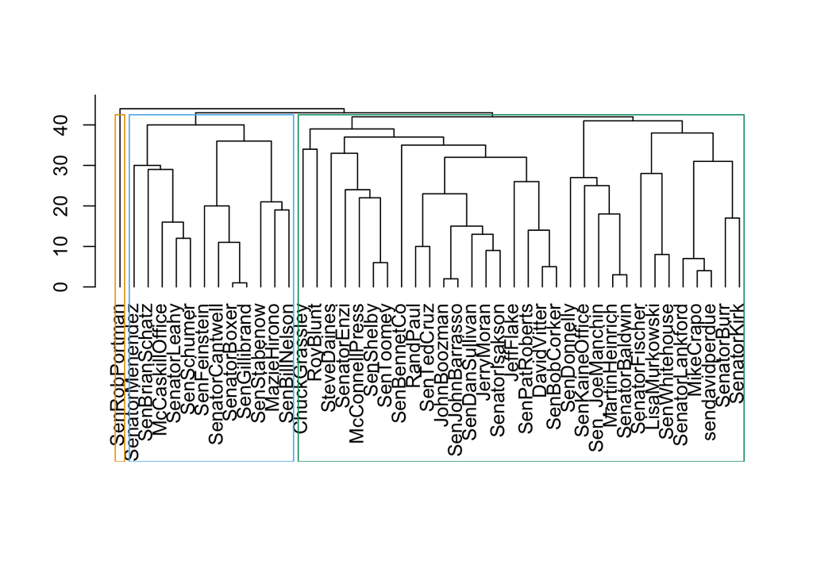

```r
wc <- walktrap.community(net)
dendPlot(wc, mode = "hclust")
```

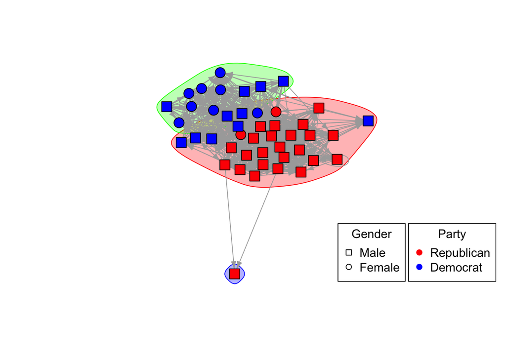

```r
V(net)$shape <- ifelse(senators$Gender == "Male", "square", "circle") # Setting shapes
V(net)$color <- ifelse(senators$party == "Republican", "red", "blue") # Setting colours

set.seed(8) # Preserve the layout. Without this, layout_with_fr() generates different layout every time
L_fr <- layout_with_fr(net) # Fruchterman-Reingold layout algorithm

plot(net, layout = L_fr, vertex.size = 10, vertex.label = NA,
     #vertex.color = senators$color, vertex.shape = senators$shape,
     edge.arrow.size = .5, edge.curved = 0, mark.groups = wc)
legend(title = "Party", x = 1.4, y = -.5, # Location of legend in x, y coordinates
       legend = c("Republican", "Democrat"),
       pch = 19, # Legend symbols, see ?points
       col = c("red", "blue"))
legend(title = "Gender", x = .7, y = -.5,
       legend = c( "Male", "Female"),
       pch = c(0, 1),
       col = "black")
```

The network plot visualises the following behaviours between the 45 senators on Twitter. An arrow symbolises a following behaviour, with the originating node of the arrow being the follower while the node the arrow is pointing towards being the followee.

The detected communities largely correspond with the party affiliation of the senators. There are 32 senators from Community 1 (in red), 25 of which are Republican while 7 are Democrat. Community 2 (in green) consists of 12 Democratic senators. @SenRobPortman, a Republican senator, forms its own Community 3 (in blue).

The reason why the community is simialr to the party affliation is because naturally senators are more likely to interact with other senators from the same party. But there are exceptions, as shown by the inclusion of 7 Democratic senators in Community 1. Looking closely into the edges connected to these nodes, these Democrats are either following more Republican than Democrats on Twitter or are followed by more Republicans than Democrats. One possible explanation is that their views on certain political issues are closer to that of the Republicans in the network (which explains the case in which they have more Republican followers). It is noted that however no Republican senator is included in Community 2. One can argue that these 25 Republican senators are less likely to defy the party line than the Democrats, if the explanation for the inclusion of Democrats in Community 1 holds true.

For the reason the one Republican that forms its own community in the network, it is likely that he is not an active user on Twitter, since he did not follow any of the 44 other senators in the network, and only has two followers from its own party.